# Create a correlation table with summary statistics in APA style

Source: [`R/cor_tables.R`](https://github.com/LukasWallrich/timesaveR/blob/master/R/cor_tables.R)

This function creates (and optionally saves) a correlation table with summary statistics. It accepts correlation matrices from various functions in this package as its first argument.

```r
report_cor_table(
  cor_matrix,
  ci_type = deprecated(),
  ci_width = deprecated(),
  ci = deprecated(),
  n = deprecated(),
  add_distributions = FALSE,
  data = NULL,
  filename = NULL,
  notes = list(NULL),
  stars = NULL,
  add_title = FALSE,
  extras = NULL,
  apa_style = TRUE,
  ...
)
```

## Source

Based on the apaTables `apa.cor.table()` function, but adapted to accept weighted correlation matrices and work with the `gt` package instead. Code for calculation of confidence intervals adapted from https://medium.com/@shandou/how-to-compute-confidence-interval-for-pearsons-r-a-brief-guide-951445b9cb2d`

## Arguments

**cor_matrix**

A correlation matrix, for example returned from `cor_matrix()`, `svy_cor_matrix()`, or `cor_matrix_mi()`.

**ci_type**

[figure not shown]

Recalculating CIs in this function has been removed. Please generate CIs in `cor_matrix()`.

**ci_width**

[figure not shown]

Use `conf_level` in `cor_matrix()` instead.

**ci**

[figure not shown]

Superseded by functionality in `cor_matrix()`.

**n**

[figure not shown]

No longer used.

**add_distributions**

Logical. Add graphs showing variable distributions? Works with both regular data frames and survey design objects.

**data**

Original data, only needed if `add_distributions = TRUE`. Can be a regular data frame or a survey design object. For survey data, distributions will be properly weighted using `svyhist()` and `svysmooth()`.

**filename**

The file name to create on disk. Include '.html' extension to best preserve formatting (see `gt::gtsave` for details).

**notes**

List of additional notes to show under the table.

**stars**

A character vector to change the significance symbols (see details below)

**add_title**

Should title be added to table? Set to TRUE for default title or provide a character string for custom title.

**extras**

Tibble of additional columns to be added after the descriptives column - needs to be sorted in the same order as the `desc` element in the `cor_matrix` unless there is a `row_names` column. If there is, this will be used to match it to the `desc` rows.

**apa_style**

Logical, should APA-style formatting be applied.

**...**

Arguments passed on to `plot_distributions`

**`plot_type`**

Type of plot that should be produced - `histogram` or `density` plot. If `auto`, histograms are produced for variables that take fewer than 10 unique values, density plots for others. If a number is provided, that number is used as the maximum number of unique values for which a histogram is used.

**`hist_align_y`**

Should histograms use the same y-axis, so that bin heights are comparable? Defaults to FALSE

**`plot_theme`**

Additional theme_ commands to be added to each plot

## Value

A `gt` table that can be further formatted with `gt`-functions.

## Examples

```r
# Basic correlation table
cor_matrix(iris, var_names = c(Sepal.Length = "Sepal Length",
                                Sepal.Width = "Sepal Width")) %>%
  report_cor_table()


  Variable
      M (SD)
      1
    Sepal Length

5.84 (0.83)

Sepal Width

3.06 (0.44)
-.12
[-0.27, 0.04]M and SD are used to represent mean and standard deviation, respectively.
    Values in square brackets indicate the confidence interval for each correlation.
    † p < .1, * p < .05, ** p < .01, *** p < .001

# With distributions
cor_matrix(iris) %>%
  report_cor_table(add_distributions = TRUE, data = iris,
                   add_title = "Iris correlations and distributions")


  Iris correlations and distributions
    Variable
      M (SD)
      Distributions
      1
      2
      3
    Sepal.Length

5.84 (0.83)






Sepal.Width

3.06 (0.44)

-.12
[-0.27, 0.04]



Petal.Length

3.76 (1.77)

.87 ***
[0.83, 0.91]
-.43 ***
[-0.55, -0.29]

Petal.Width

1.20 (0.76)

.82 ***
[0.76, 0.86]
-.37 ***
[-0.50, -0.22]
.96 ***
[0.95, 0.97]M and SD are used to represent mean and standard deviation, respectively.
    Values in square brackets indicate the confidence interval for each correlation.
    † p < .1, * p < .05, ** p < .01, *** p < .001

# Using ESS health data
cor_matrix(ess_health, var_names = c(health = "Health",
                                      dosprt = "Physical activity",
                                      etfruit = "Fruit consumption")) %>%
  report_cor_table()


  Variable
      M (SD)
      1
      2
    Health

2.26 (0.92)



Physical activity

3.26 (2.65)
-.18 ***
[-0.20, -0.16]

Fruit consumption

3.04 (1.43)
.06 ***
[0.04, 0.08]
-.11 ***
[-0.13, -0.09]M and SD are used to represent mean and standard deviation, respectively.
    Values in square brackets indicate the confidence interval for each correlation.
    † p < .1, * p < .05, ** p < .01, *** p < .001

# With survey data and distributions
if (FALSE) { # \dontrun{
library(survey)
library(srvyr)
data(api)
dstrat <- apistrat %>% as_survey_design(1, strata = stype, fpc = fpc, weight = pw)
svy_cor_matrix(dstrat, var_names = c(enroll = "Enrollment",
                                      api00 = "API 2000",
                                      api99 = "API 1999")) %>%
  report_cor_table(add_distributions = TRUE, data = dstrat)
} # }
```

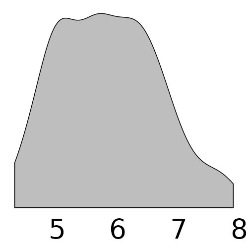

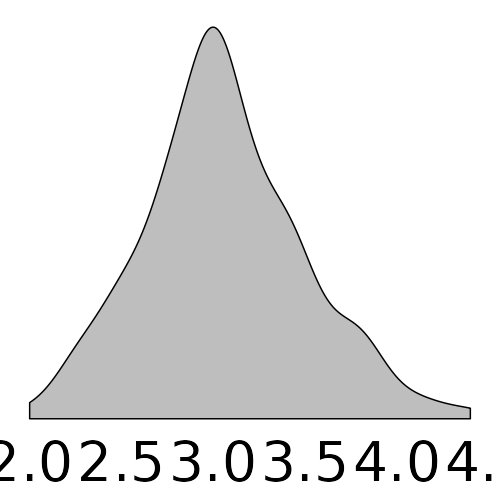

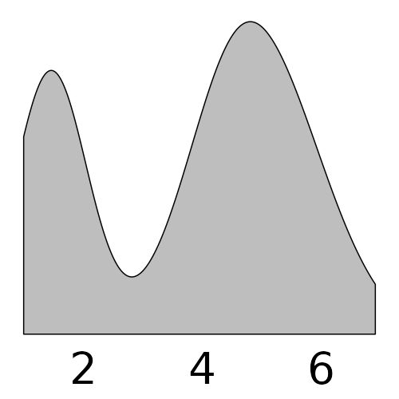

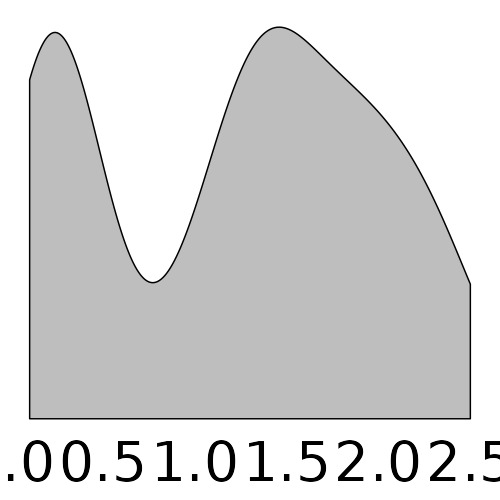